# Archetypal Ballers and Ternary Plots

M. Edward (Ed) Borasky ([@znmeb_dfs](https://twitter.com/znmeb_dfs))

February 9, 2017

# Archetypal Analysis (Eugster and Leisch 2009)

- Goal:
  - Dimensionality reduction
  - Reduce a dataset with 17 box score metrics to three archetypes
  - Represent players’ skills in terms of the archetypes
- Inputs:
  - Player box scores for the season (2016-17 to date)
  - About 450 players
- Outputs:
  - Archetype table
  - Player table

# The Three Archetypes

- Weighted box score metrics
- Each archetype represents a skill set
  - Front: skills for a frontcourt player (Center, Power Forward, Small Forward)
    - dominated by rebounds
  - Back: skills for a backcourt player (Point Guard, Shooting Guard)
    - dominated by three-point shots
  - Bench: the “bad” archetype - players with low overall skills

# The Player Table

- For each player, the percentage of a player’s skill in each archetype
- Total of Front, Back and Bench for each player is 1.0
- Sum of Front and Back represents Overall skill
- The archetypal player is the one with the largest value for the archetype
- So who are the archetypal players?

# Top Twelve Backcourt

| Player | Position | Team | Back | Front | Overall |
| --- | --- | --- | --- | --- | --- |
| James Harden | PG | Houston | 1.0000 | 0.0000 | 1.0000 |
| Russell Westbrook | PG | Oklahoma City | 0.9998 | 0.0000 | 0.9998 |
| Stephen Curry | PG | Golden State | 0.9990 | 0.0000 | 0.9990 |
| Isaiah Thomas | PG | Boston | 0.9989 | 0.0000 | 0.9989 |
| Kyle Lowry | PG | Toronto | 0.9989 | 0.0000 | 0.9989 |
| Damian Lillard | PG | Portland | 0.9265 | 0.0468 | 0.9732 |
| Kemba Walker | PG | Charlotte | 0.9195 | 0.0000 | 0.9195 |
| CJ McCollum | SG | Portland | 0.8445 | 0.0856 | 0.9301 |
| Eric Bledsoe | PG | Phoenix | 0.8413 | 0.1576 | 0.9989 |
| Kyrie Irving | PG | Cleveland | 0.8279 | 0.0000 | 0.8279 |
| Devin Booker | SG | Phoenix | 0.8244 | 0.0520 | 0.8764 |
| Klay Thompson | SG | Golden State | 0.8047 | 0.0000 | 0.8047 |

# Top Twelve Frontcourt

| Player | Position | Team | Back | Front | Overall |
| --- | --- | --- | --- | --- | --- |
| Rudy Gobert | C | Utah | 0.0000 | 1.0000 | 1.0000 |
| Andre Drummond | C | Detroit | 0.0000 | 0.9998 | 0.9998 |
| Hassan Whiteside | C | Miami | 0.0000 | 0.9998 | 0.9998 |
| DeAndre Jordan | C | LA Clippers | 0.0000 | 0.9997 | 0.9997 |
| Dwight Howard | C | Atlanta | 0.0000 | 0.9996 | 0.9996 |
| Marcin Gortat | C | Washington | 0.0000 | 0.9994 | 0.9994 |
| Nikola Vucevic | C | Orlando | 0.0876 | 0.9000 | 0.9876 |
| Jonas Valanciunas | C | Toronto | 0.0000 | 0.8984 | 0.8984 |
| Tristan Thompson | C | Cleveland | 0.0000 | 0.8927 | 0.8927 |
| Steven Adams | C | Oklahoma City | 0.0233 | 0.8708 | 0.8941 |
| Anthony Davis | PF | New Orleans | 0.1481 | 0.8518 | 0.9999 |
| Myles Turner | C | Indiana | 0.1705 | 0.8273 | 0.9978 |

# Top Twelve Overall #BallIsLife

| Player | Position | Team | Back | Front | Overall |
| --- | --- | --- | --- | --- | --- |
| James Harden | PG | Houston | 1.0000 | 0.0000 | 1.0000 |
| Rudy Gobert | C | Utah | 0.0000 | 1.0000 | 1.0000 |
| Anthony Davis | PF | New Orleans | 0.1481 | 0.8518 | 0.9999 |
| Karl-Anthony Towns | C | Minnesota | 0.1784 | 0.8215 | 0.9999 |
| Andre Drummond | C | Detroit | 0.0000 | 0.9998 | 0.9998 |
| DeMarcus Cousins | C | New Orleans | 0.5557 | 0.4441 | 0.9998 |
| Russell Westbrook | PG | Oklahoma City | 0.9998 | 0.0000 | 0.9998 |
| Hassan Whiteside | C | Miami | 0.0000 | 0.9998 | 0.9998 |
| DeAndre Jordan | C | LA Clippers | 0.0000 | 0.9997 | 0.9997 |
| Dwight Howard | C | Atlanta | 0.0000 | 0.9996 | 0.9996 |
| Giannis Antetokounmpo | SG | Milwaukee | 0.4001 | 0.5994 | 0.9996 |
| Marcin Gortat | C | Washington | 0.0000 | 0.9994 | 0.9994 |

# Ternary Plots (Hamilton 2016)

“A ternary plot, ternary graph, triangle plot, simplex plot, or de Finetti diagram is a barycentric plot on three variables which sum to a constant. It graphically depicts the ratios of the three variables as positions in an equilateral triangle.” - https://en.wikipedia.org/wiki/Ternary_plot

- But that’s exactly what each entry in the player table is!
  - Three variables - Front, Back and Bench - that sum to a constant 1.0.
- So we can plot players as points on a ternary plot.

# Top Twelve Backcourt

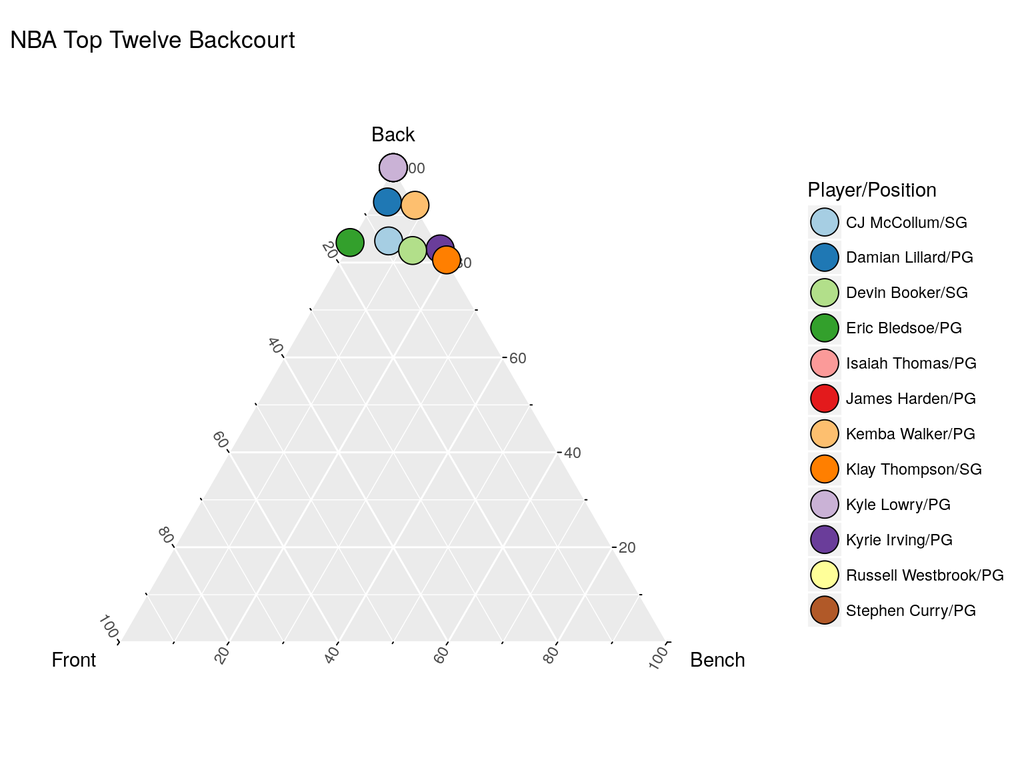

# Top Twelve Frontcourt

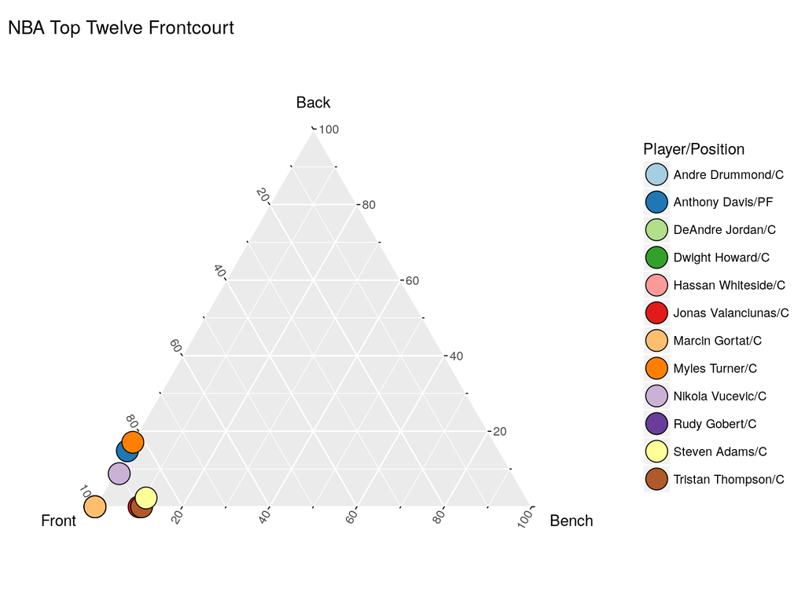

# Top Twelve Overall #ThisIsWhyWePlay

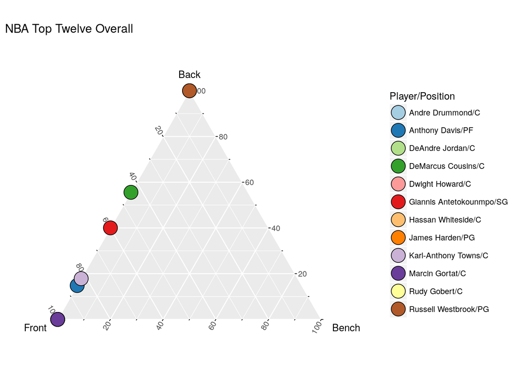

# Portland Trail Blazers #RipCity

| Player | Position | Team | Back | Front | Overall |
| --- | --- | --- | --- | --- | --- |
| Damian Lillard | PG | Portland | 0.9265 | 0.0468 | 0.9732 |
| CJ McCollum | SG | Portland | 0.8445 | 0.0856 | 0.9301 |
| Maurice Harkless | SF | Portland | 0.2393 | 0.3796 | 0.6189 |
| Jusuf Nurkic | C | Portland | 0.0090 | 0.4807 | 0.4897 |
| Allen Crabbe | SG | Portland | 0.4090 | 0.0510 | 0.4599 |
| Evan Turner | SG | Portland | 0.2744 | 0.1789 | 0.4533 |
| Al-Farouq Aminu | SF | Portland | 0.1486 | 0.2607 | 0.4093 |
| Ed Davis | PF | Portland | 0.0000 | 0.3695 | 0.3695 |
| Meyers Leonard | PF | Portland | 0.1505 | 0.1229 | 0.2734 |
| Noah Vonleh | PF | Portland | 0.0000 | 0.2616 | 0.2616 |
| Shabazz Napier | PG | Portland | 0.0413 | 0.0000 | 0.0413 |

# Portland Trail Blazers

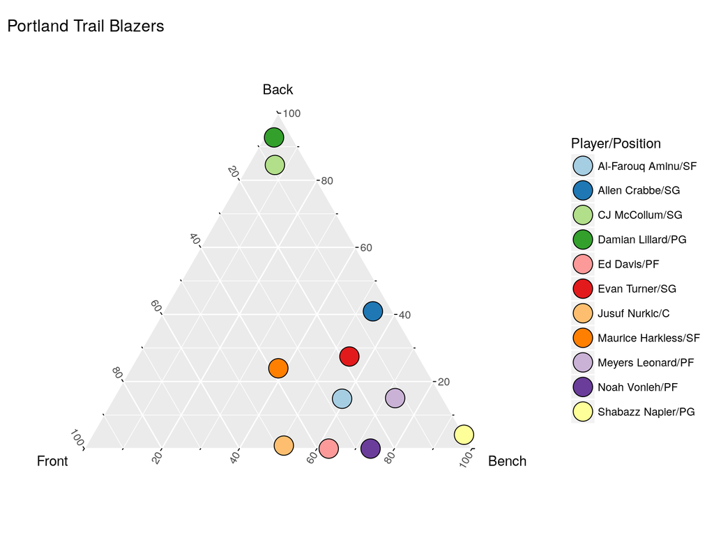

# Pop Quiz!

1. Who is the archetypal backcourt player?
2. Who is the archetypal frontcourt player?
3. Who are the three best Trail Blazers?

# References

Eugster, Manuel J. A., and Friedrich Leisch. 2009. “From Spider-Man to Hero – Archetypal Analsis in R.” *Journal of Statistical Software* 30 (8): 1–23. http://www.jstatsoft.org/v30/i08/.

Hamilton, Nicholas. 2016. *Ggtern: An Extension to ’Ggplot2’, for the Creation of Ternary Diagrams*. https://CRAN.R-project.org/package=ggtern.

Oliver, D. 2004. *Basketball on Paper: Rules and Tools for Performance Analysis*. Brassey’s, Incorporated.

Shea, S.M. 2014. *Basketball Analytics: Spatial Tracking*. CreateSpace Independent Publishing Platform.

Shea, S.M., and C.E. Baker. 2013. *Basketball Analytics: Objective and Efficient Strategies for Understanding How Teams Win*. Createspace Independent Pub.